# Machine Learning: AllLife Bank Personal Loan Campaign

## Problem Statement

### Context

AllLife Bank is a US bank that has a growing customer base. The majority of these customers are liability customers (depositors) with varying sizes of deposits. The number of customers who are also borrowers (asset customers) is quite small, and the bank is interested in expanding this base rapidly to bring in more loan business and in the process, earn more through the interest on loans. In particular, the management wants to explore ways of converting its liability customers to personal loan customers (while retaining them as depositors).

A campaign that the bank ran last year for liability customers showed a healthy conversion rate of over 9% success. This has encouraged the retail marketing department to devise campaigns with better target marketing to increase the success ratio.

You as a Data scientist at AllLife bank have to build a model that will help the marketing department to identify the potential customers who have a higher probability of purchasing the loan.

### Objective

To predict whether a liability customer will buy personal loans, to understand which customer attributes are most significant in driving purchases, and identify which segment of customers to target more.

### Data Dictionary

- `ID`: Customer ID
- `Age`: Customer’s age in completed years
- `Experience`: #years of professional experience
- `Income`: Annual income of the customer (in thousand dollars)
- `ZIP Code`: Home Address ZIP code.
- `Family`: the Family size of the customer
- `CCAvg`: Average spending on credit cards per month (in thousand dollars)
- `Education`: Education Level. 1: Undergrad; 2: Graduate;3: Advanced/Professional
- `Mortgage`: Value of house mortgage if any. (in thousand dollars)
- `Personal_Loan`: Did this customer accept the personal loan offered in the last campaign? (0: No, 1: Yes)
- `Securities_Account`: Does the customer have securities account with the bank? (0: No, 1: Yes)
- `CD_Account`: Does the customer have a certificate of deposit (CD) account with the bank? (0: No, 1: Yes)
- `Online`: Do customers use internet banking facilities? (0: No, 1: Yes)
- `CreditCard`: Does the customer use a credit card issued by any other Bank (excluding All life Bank)? (0: No, 1: Yes)

## Importing necessary libraries

```python
# Installing the libraries with the specified version.
!pip install numpy==1.25.2 pandas==1.5.3 matplotlib==3.7.1 seaborn==0.13.1 scikit-learn==1.2.2 sklearn-pandas==2.2.0 -q --user
```

**Note**: *After running the above cell, kindly restart the notebook kernel and run all cells sequentially from the start again.*

```python
# import libraries for data manipulation
import numpy as np
import pandas as pd

# import libraries for data visualization
import matplotlib.pyplot as plt
import seaborn as sns

from sklearn import metrics
from sklearn.model_selection import train_test_split
from sklearn.tree import DecisionTreeClassifier
from sklearn import tree
```

## Loading the dataset

```python
from google.colab import drive
drive.mount('/content/drive')
```

```python
loan_data = pd.read_csv('/content/drive/MyDrive/Loan_Modelling.csv')
```

## Data Overview

- Observations
- Sanity checks

```python
# check the first 10 rows
loan_data.head(10)
```

|  | ID | Age | Experience | Income | ZIPCode | Family | CCAvg | Education | Mortgage | Personal_Loan | Securities_Account | CD_Account | Online | CreditCard |
| --- | --- | --- | --- | --- | --- | --- | --- | --- | --- | --- | --- | --- | --- | --- |
| 0 | 1 | 25 | 1 | 49 | 91107 | 4 | 1.6 | 1 | 0 | 0 | 1 | 0 | 0 | 0 |
| 1 | 2 | 45 | 19 | 34 | 90089 | 3 | 1.5 | 1 | 0 | 0 | 1 | 0 | 0 | 0 |
| 2 | 3 | 39 | 15 | 11 | 94720 | 1 | 1.0 | 1 | 0 | 0 | 0 | 0 | 0 | 0 |
| 3 | 4 | 35 | 9 | 100 | 94112 | 1 | 2.7 | 2 | 0 | 0 | 0 | 0 | 0 | 0 |
| 4 | 5 | 35 | 8 | 45 | 91330 | 4 | 1.0 | 2 | 0 | 0 | 0 | 0 | 0 | 1 |
| 5 | 6 | 37 | 13 | 29 | 92121 | 4 | 0.4 | 2 | 155 | 0 | 0 | 0 | 1 | 0 |
| 6 | 7 | 53 | 27 | 72 | 91711 | 2 | 1.5 | 2 | 0 | 0 | 0 | 0 | 1 | 0 |
| 7 | 8 | 50 | 24 | 22 | 93943 | 1 | 0.3 | 3 | 0 | 0 | 0 | 0 | 0 | 1 |
| 8 | 9 | 35 | 10 | 81 | 90089 | 3 | 0.6 | 2 | 104 | 0 | 0 | 0 | 1 | 0 |
| 9 | 10 | 34 | 9 | 180 | 93023 | 1 | 8.9 | 3 | 0 | 1 | 0 | 0 | 0 | 0 |

```python
# check rows and columns in data
shape = loan_data.shape
print(shape)
```

```
(5000, 14)
```

Observations:

There are 5000 rows with 14 columns.

```python
# check the data type
loan_data.info()
```

```
<class 'pandas.core.frame.DataFrame'>
RangeIndex: 5000 entries, 0 to 4999
Data columns (total 14 columns):
 #   Column              Non-Null Count  Dtype
---  ------              --------------  -----
 0   ID                  5000 non-null   int64
 1   Age                 5000 non-null   int64
 2   Experience          5000 non-null   int64
 3   Income              5000 non-null   int64
 4   ZIPCode             5000 non-null   int64
 5   Family              5000 non-null   int64
 6   CCAvg               5000 non-null   float64
 7   Education           5000 non-null   int64
 8   Mortgage            5000 non-null   int64
 9   Personal_Loan       5000 non-null   int64
 10  Securities_Account  5000 non-null   int64
 11  CD_Account          5000 non-null   int64
 12  Online              5000 non-null   int64
 13  CreditCard          5000 non-null   int64
dtypes: float64(1), int64(13)
memory usage: 547.0 KB
```

Observations:

There are 14 numerical columns in the data. The two different data types are int and float.

```python
# checking for missing values
loan_data.isnull().sum()
```

```
ID                    0
Age                   0
Experience            0
Income                0
ZIPCode               0
Family                0
CCAvg                 0
Education             0
Mortgage              0
Personal_Loan         0
Securities_Account    0
CD_Account            0
Online                0
CreditCard            0
dtype: int64
```

Observations:

There are no missing values in any columns.

```python
loan_data.describe(include = 'all').T
```

|  | count | mean | std | min | 25% | 50% | 75% | max |
| --- | --- | --- | --- | --- | --- | --- | --- | --- |
| ID | 5000.0 | 2500.500000 | 1443.520003 | 1.0 | 1250.75 | 2500.5 | 3750.25 | 5000.0 |
| Age | 5000.0 | 45.338400 | 11.463166 | 23.0 | 35.00 | 45.0 | 55.00 | 67.0 |
| Experience | 5000.0 | 20.104600 | 11.467954 | -3.0 | 10.00 | 20.0 | 30.00 | 43.0 |
| Income | 5000.0 | 73.774200 | 46.033729 | 8.0 | 39.00 | 64.0 | 98.00 | 224.0 |
| ZIPCode | 5000.0 | 93169.257000 | 1759.455086 | 90005.0 | 91911.00 | 93437.0 | 94608.00 | 96651.0 |
| Family | 5000.0 | 2.396400 | 1.147663 | 1.0 | 1.00 | 2.0 | 3.00 | 4.0 |
| CCAvg | 5000.0 | 1.937938 | 1.747659 | 0.0 | 0.70 | 1.5 | 2.50 | 10.0 |
| Education | 5000.0 | 1.881000 | 0.839869 | 1.0 | 1.00 | 2.0 | 3.00 | 3.0 |
| Mortgage | 5000.0 | 56.498800 | 101.713802 | 0.0 | 0.00 | 0.0 | 101.00 | 635.0 |
| Personal_Loan | 5000.0 | 0.096000 | 0.294621 | 0.0 | 0.00 | 0.0 | 0.00 | 1.0 |
| Securities_Account | 5000.0 | 0.104400 | 0.305809 | 0.0 | 0.00 | 0.0 | 0.00 | 1.0 |
| CD_Account | 5000.0 | 0.060400 | 0.238250 | 0.0 | 0.00 | 0.0 | 0.00 | 1.0 |
| Online | 5000.0 | 0.596800 | 0.490589 | 0.0 | 0.00 | 1.0 | 1.00 | 1.0 |
| CreditCard | 5000.0 | 0.294000 | 0.455637 | 0.0 | 0.00 | 0.0 | 1.00 | 1.0 |

Observations:

## Exploratory Data Analysis.

- EDA is an important part of any project involving data.
- It is important to investigate and understand the data better before building a model with it.
- A few questions have been mentioned below which will help you approach the analysis in the right manner and generate insights from the data.
- A thorough analysis of the data, in addition to the questions mentioned below, should be done.

**Questions**:

1. What is the distribution of mortgage attribute? Are there any noticeable patterns or outliers in the distribution?
2. How many customers have credit cards?
3. What are the attributes that have a strong correlation with the target attribute (personal loan)?
4. How does a customer's interest in purchasing a loan vary with their age?
5. How does a customer's interest in purchasing a loan vary with their education?

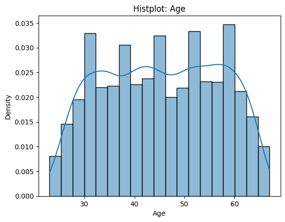

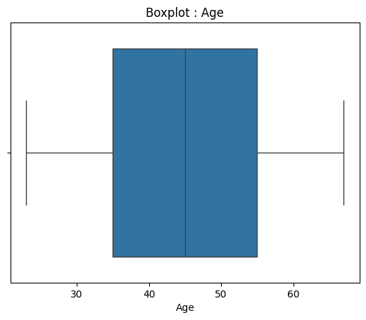

```python
# plot of variable age
# Histplot

sns.histplot(data=loan_data, x = 'Age', stat = 'density', kde = True)
plt.title('Histplot: Age')
plt.show();

# Boxplot
sns.boxplot(data=loan_data, x = 'Age')
plt.title('Boxplot : Age')
plt.show();
```

Observations

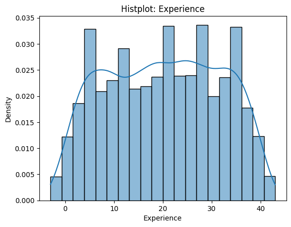

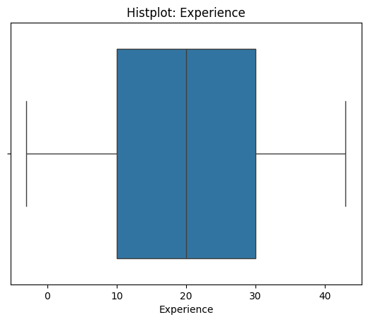

```python
# plot variable experience
# Histplot
sns.histplot(data=loan_data, x = 'Experience', stat = 'density', kde = 'true')
plt.title('Histplot: Experience')
plt.show()

#Boxplot
sns.boxplot(data=loan_data, x = 'Experience')
plt.title('Histplot: Experience')
plt.show()
```

Observations:

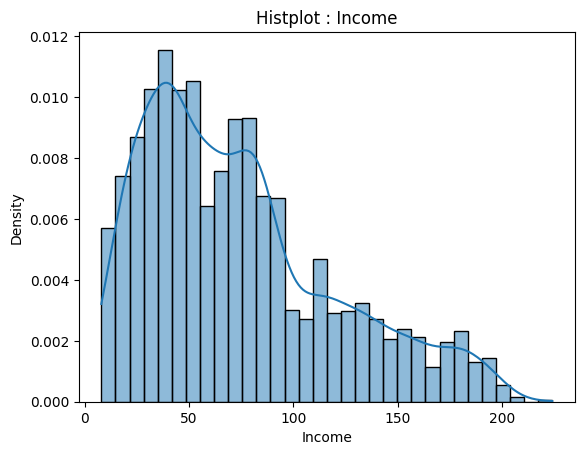

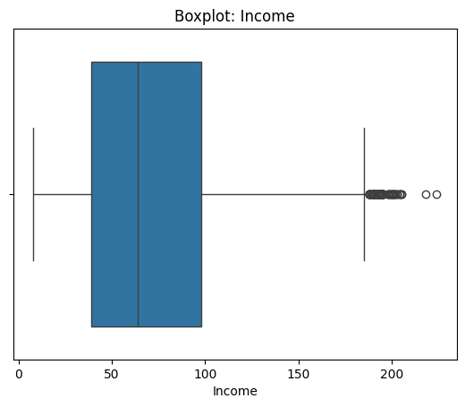

```python
# plot variable income
# Histplot
sns.histplot(data=loan_data, x = 'Income', stat = 'density', kde = 'true')
plt.title('Histplot : Income')
plt.show()

#Boxplot
sns.boxplot(data=loan_data, x = 'Income')
plt.title('Boxplot: Income')
plt.show()
```

Observations:

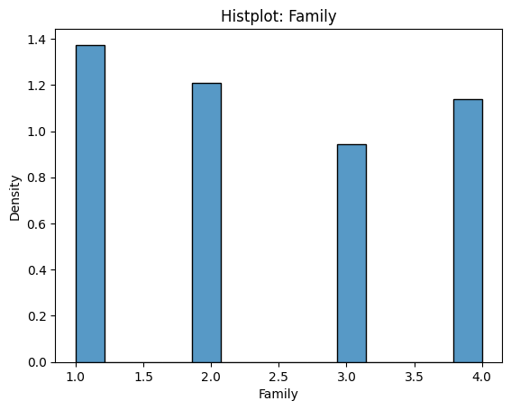

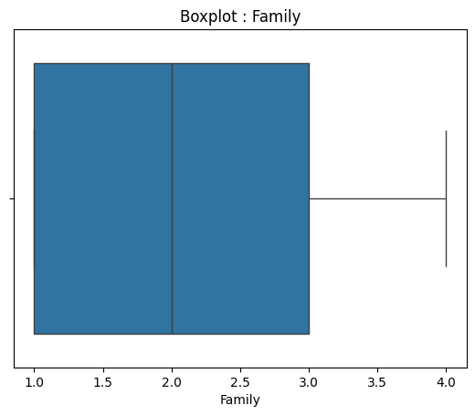

```python
# plot variable Family
# Histplot
sns.histplot(data=loan_data, x = 'Family', stat = 'density',)
plt.title('Histplot: Family')
plt.show()

#Boxplot
sns.boxplot(data=loan_data, x = 'Family')
plt.title("Boxplot : Family")
plt.show()
```

Observations:

- The family size ranges from 1 to 4.
- The data is normal skew.

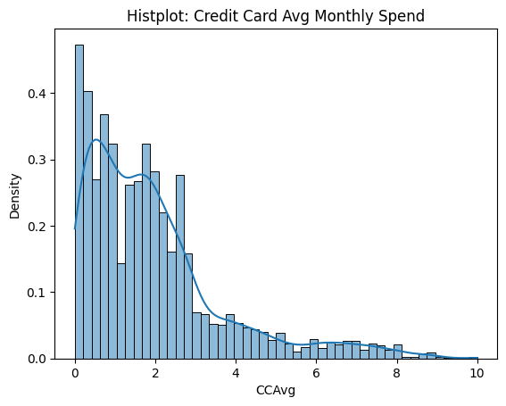

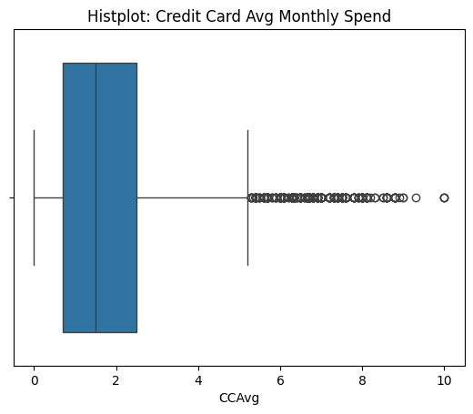

```python
# plot variable credit card average
# Histplot
sns.histplot(data=loan_data, x = "CCAvg", stat = 'density', kde = True)
plt.title('Histplot: Credit Card Avg Monthly Spend')
plt.show()

#Boxplot
sns.boxplot(data=loan_data, x = 'CCAvg')
plt.title('Histplot: Credit Card Avg Monthly Spend')
plt.show()
```

Observations:

- The data is right skewed.
- There are several outliers present.
- The minimum amount of monthly credit card spend is 0 dollars and the maximum is 10K dollars.
- The median monthly credit card spend is around 1.6K.

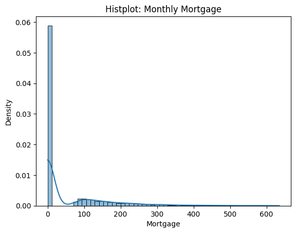

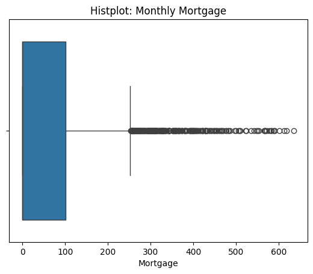

```python
# plot variable mortgage
# Histplot
sns.histplot(data=loan_data, x = 'Mortgage', stat = 'density', kde = True)
plt.title('Histplot: Monthly Mortgage')
plt.show()

#Boxplot
sns.boxplot(data = loan_data, x = 'Mortgage')
plt.title('Histplot: Monthly Mortgage')
plt.show()
```

Observations:

```python
# extracting first 2 digits of zip code and putting the zip code in a new column
loan_data['ZipCode_First2Digits'] = loan_data['ZIPCode'].astype(str).str[:2]
```

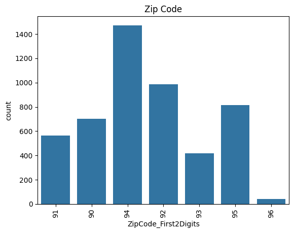

```python
# plot variable zip code
# countplot
sns.countplot(data = loan_data, x = 'ZipCode_First2Digits').set(title = 'Zip Code')
plt.xticks(rotation=90);
plt.show();
```

Observations:

- Zip Codes starting with digits '94' appear to be most frequent.
- Least frequent Zip Code are ones starting with '96'.

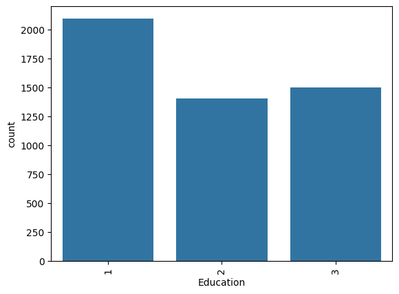

```python
# plot variable education
# countplot
sns.countplot(data=loan_data, x = 'Education')
plt.xticks(rotation=90)
plt.show()
```

Observations:

- There are 3 categories for education. 1 = Undergrad, 2 = Graduate, 3 = Working Professional.
- It appears that the highest number of customers are undergrad students followed by working professional and then graduates.

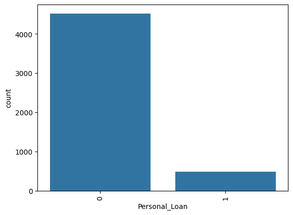

```python
# plot variable Personal loan
# countplot
sns.countplot(data=loan_data, x = 'Personal_Loan')
plt.xticks(rotation=90)
plt.show()
```

Observations:

- 0 = no 1 = Yes.
- So, it appears most people did not accept loan that's why the number of zeroes are higher. There are much fewer people that actually did take loans.

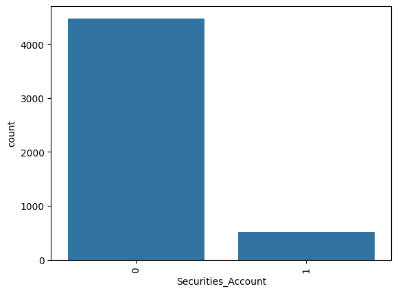

```python
# plot variable securities account
# countplot
sns.countplot(data=loan_data, x = 'Securities_Account')
plt.xticks(rotation=90)
plt.show()
```

Observations:

- 0 = no, 1 = yes
- It appears majority of the people do not have a securities account with the bank. Only a small chunk have a securities account.

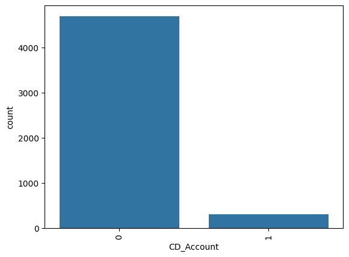

```python
# plot variable CD account
# countplot
sns.countplot(data=loan_data, x = 'CD_Account')
plt.xticks(rotation=90)
plt.show()
```

Observations:

- 0 = no, 1 = yes.
- It appears most people do not have a certificate of deposit account with the bank. Only some have a certificate of deposit account.

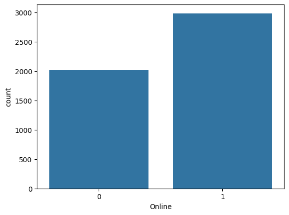

```python
# plot variable online
# countplot
sns.countplot(data=loan_data, x = 'Online')
plt.xticks()
plt.show();
```

Observations:

- 0 = no, 1 = yes.
- It appears most people do use the online facilities for the bank. However, there are many people that do not use it as well.

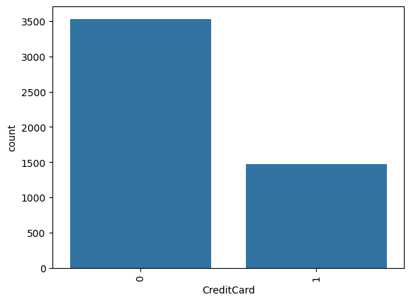

```python
# plot variable Credit card
# countplot
sns.countplot(data=loan_data, x = 'CreditCard')
plt.xticks(rotation=90)
plt.show()
```

Observations:

- 0 = no, 1 = yes.
- It appears most people do not own a credit card from other banks excluding AllBank. However, there are some people that do own credit cards from other banks.

How many people own credit cards?

```python
# check how many people own a credit card
# count the number of people who have credit card
count_with_credit_card = loan_data['CreditCard'].sum()

print(f"Number of people who own credit cards: {count_with_credit_card}")
```

```
Number of people who own credit cards: 1470
```

Observations:

- Number of people who own credit cards is 1470.

Which attributes have a strong correlation with the target attribute (Personal loan)?

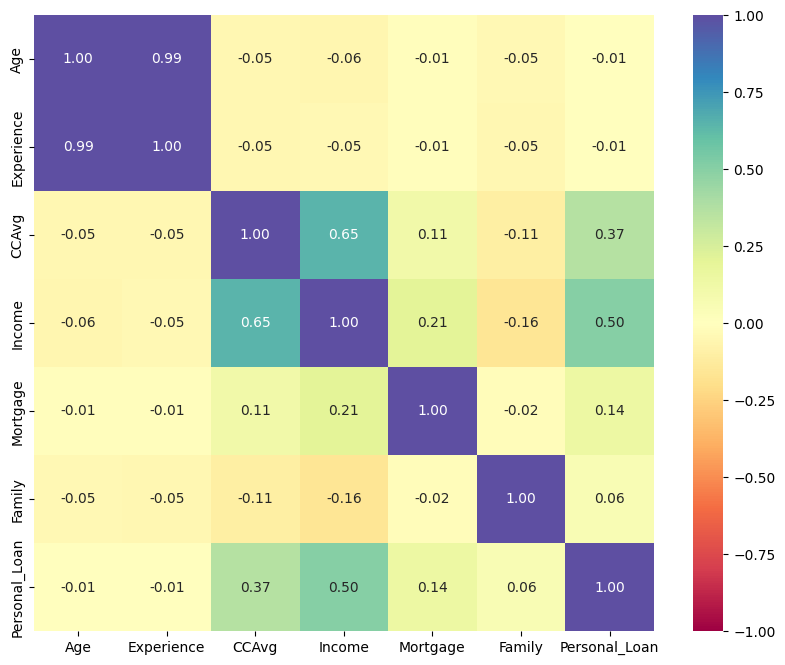

```python
# check for correlation among numerical columns
num_var = ['Age', 'Experience', 'CCAvg', 'Income', 'Mortgage', 'Family']
target = 'Personal_Loan'
# combine numerical column and target column
cols=num_var + [target]

#calculate the correlation
corr = loan_data[cols].corr()
# plot heatmap
plt.figure(figsize = (10,8))
sns.heatmap(corr, annot = True, vmin=-1, vmax=1, fmt=".2f", cmap = 'Spectral')
plt.show()
```

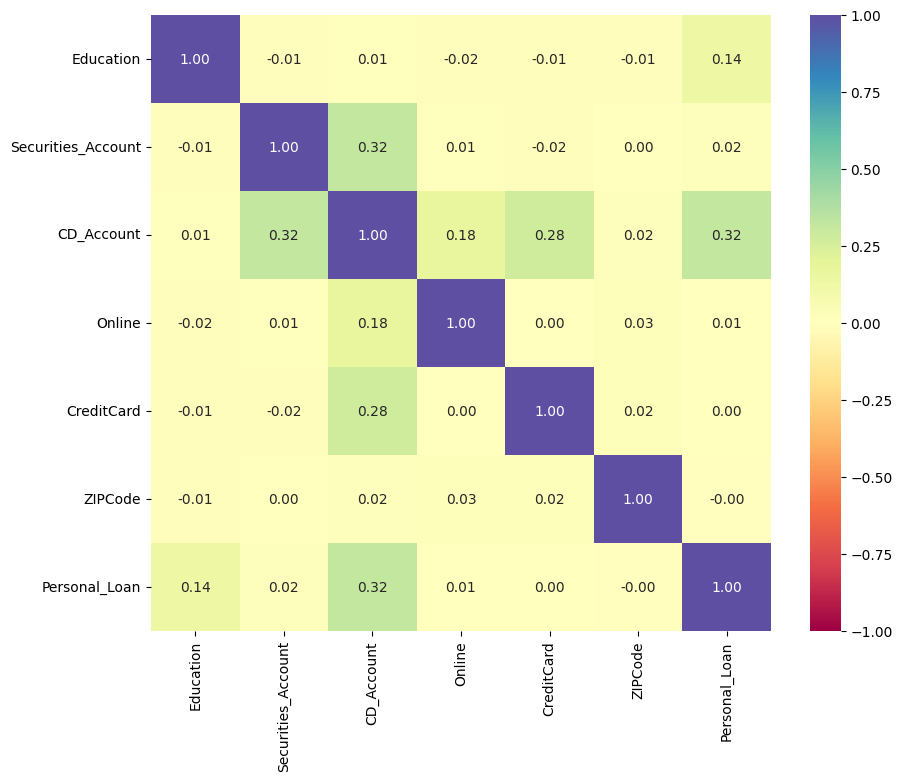

```python
# check correlation between categorical columns and target column Personal loan

cat_var = ['Education', 'Securities_Account', 'CD_Account', 'Online', 'CreditCard','ZIPCode']
target = 'Personal_Loan'
# combine numerical column and target column
cols=cat_var + [target]

#calculate the correlation
corr = loan_data[cols].corr()
# plot heatmap
plt.figure(figsize = (10,8))
sns.heatmap(corr, annot = True, vmin=-1, vmax=1, fmt=".2f", cmap = 'Spectral')
plt.show()
```

Observations:

- Mortgage, Income, Family,CD_Account,Securities_Account,Education,Online and CCAvg have a positive correlation with Personal Loan.
- Income has the strongest correlation with Personal Loan.
- Experience,Age, and Zip Code have a negative correlation with Personal Loan.

**How does a customer's interest in purchasing a loan vary with their age?**

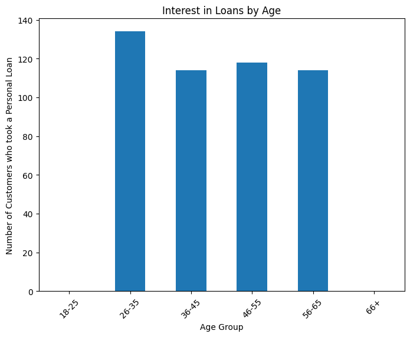

```python
# create age bins
bins = [18,25,35,45,55,65,100]
labels = ['18-25', '26-35', '36-45', '46-55','56-65','66+']
loan_data['AgeGroup'] = pd.cut(loan_data['Age'], bins=bins, labels=labels, include_lowest = True)

# calculate percentage of customers who took a personal loan in each age group
loan_count = loan_data.groupby('AgeGroup')['Personal_Loan'].sum()

# plot the results
plt.figure(figsize=(8,6))
loan_count.plot(kind = 'bar')
plt.xlabel ('Age Group')
plt.ylabel ('Number of Customers who took a Personal Loan')
plt.title('Interest in Loans by Age')
plt.xticks(rotation=45)
plt.show()
```

Observations:

- The age group of 26-35 have the highest number of loans taken.
- 18-25 years old have not taken any loans.
- I don't think age affects a customer's interest in taking a loan because all the age groups take loans and there isn't a specific pattern here.

How does a customer's interest in purchasing a loan vary with their education?

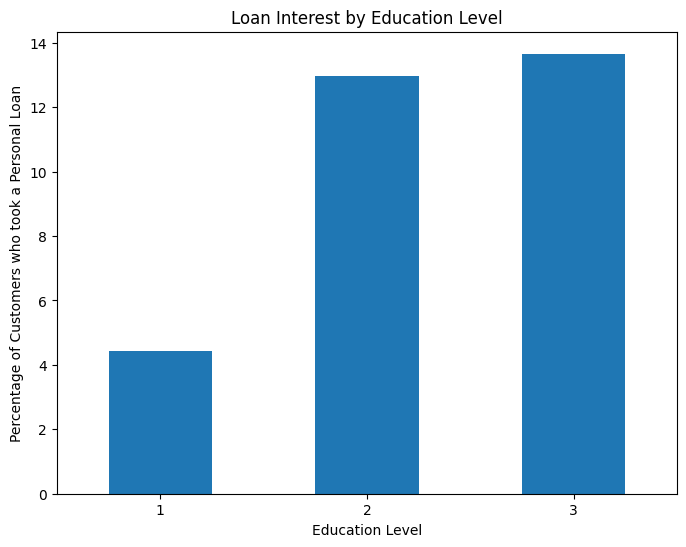

```python
# calculate percentage of customers who took a personal loan in each education group
loan_percentage = loan_data.groupby('Education')['Personal_Loan'].mean() * 100

# plot the results
plt.figure(figsize=(8,6))
loan_percentage.plot(kind = 'bar')
plt.xlabel ('Education Level')
plt.ylabel ('Percentage of Customers who took a Personal Loan')
plt.title('Loan Interest by Education Level')
plt.xticks(rotation=0)
plt.show()
```

Observations:

- The percentage of people that take the highest amount of loans are working professionals which is the group '3'.
- Group '1' which is undergraduates don't take as many loans.
- Group '2' which is graduates also take a high amount of loans almost close with working professionals.
- The reason for working professionals taking the highest percent of loans is most likely due to car loans, home loans, or other reasons. And graduates usually take it for student loans possibly. However, education does seem to play a role in whether or not a person accepts a loan.

### Bivariate Analysis

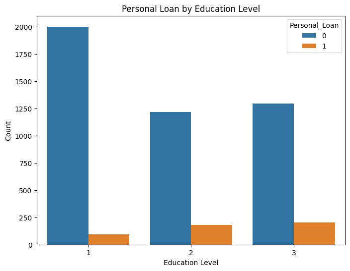

```python
# analysis between variable personal loan and education

plt.figure(figsize=(8, 6))
sns.countplot(x='Education', hue='Personal_Loan', data=loan_data)
plt.title('Personal Loan by Education Level')
plt.xlabel('Education Level')
plt.ylabel('Count')
plt.show()
```

Observations:

- Education level does play a role on the acceptance of a personal loan because category 1 which is undergrad most said no to taking a loan and very few took a loan. As you get to category 3 which is a working professional there are more yes then category 1.

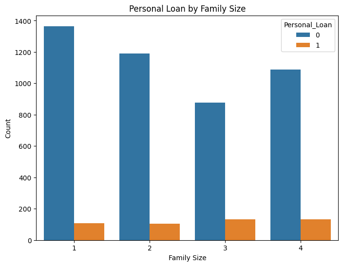

```python
# analysis between personal loan and family size
plt.figure(figsize=(8, 6))
sns.countplot(x='Family', hue='Personal_Loan', data=loan_data)
plt.title('Personal Loan by Family Size')
plt.xlabel('Family Size')
plt.ylabel('Count')
plt.show()
```

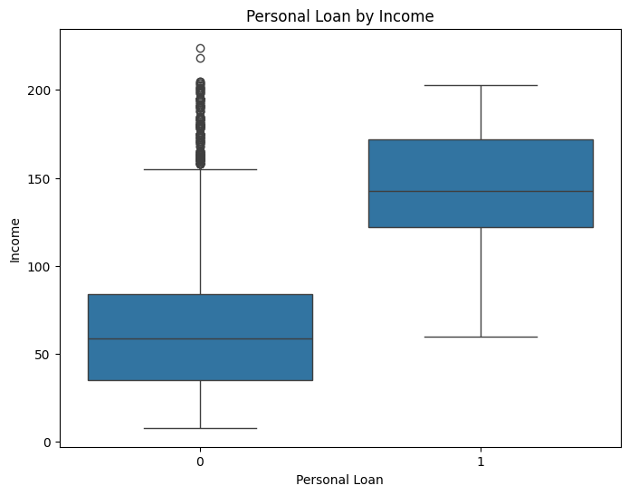

```python
# Box plot for Income vs Personal_Loan
plt.figure(figsize=(8, 6))
sns.boxplot(x='Personal_Loan', y='Income', data=loan_data)
plt.title('Personal Loan by Income')
plt.xlabel('Personal Loan')
plt.ylabel('Income')
plt.show()
```

Observations:

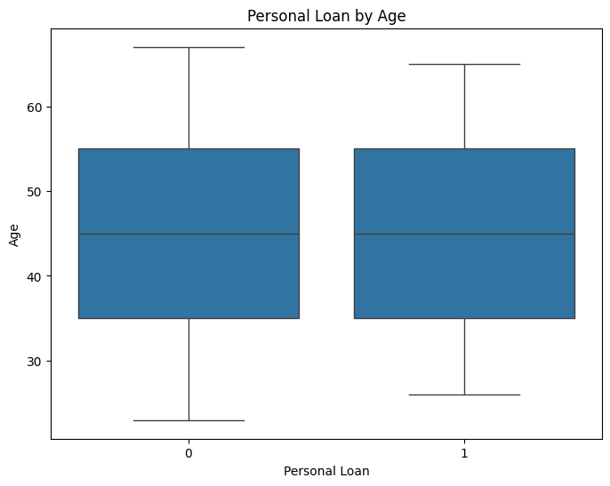

```python
# Box plot for Age vs Personal_Loan
plt.figure(figsize=(8, 6))
sns.boxplot(x='Personal_Loan', y='Age', data=loan_data)
plt.title('Personal Loan by Age')
plt.xlabel('Personal Loan')
plt.ylabel('Age')
plt.show()
```

Observations:

- Group '0' which is people who did not accept a loan and group '1' who did accept the loan both have same median for age and it appears age doesn't play as much of a role in determining whether a person accepts a loan or not.

## Data Preprocessing

- Missing value treatment
- Feature engineering (if needed)
- Outlier detection and treatment (if needed)
- Preparing data for modeling
- Any other preprocessing steps (if needed)

```python
# check for missing values
loan_data.isnull().sum()
```

```
ID                      0
Age                     0
Experience              0
Income                  0
ZIPCode                 0
Family                  0
CCAvg                   0
Education               0
Mortgage                0
Personal_Loan           0
Securities_Account      0
CD_Account              0
Online                  0
CreditCard              0
ZipCode_First2Digits    0
AgeGroup                0
dtype: int64
```

Observations:

- There are no null values in any columns.

Split Data

```python
# Split Data

from sklearn.model_selection import train_test_split
from sklearn.preprocessing import OneHotEncoder


# Split data into features (X) and target (y)
X = loan_data.drop(['Personal_Loan'], axis=1)
y = loan_data['Personal_Loan']

# convert age_group to categorical type

X['AgeGroup'] = X['AgeGroup'].astype('category')

# One-hot encode AgeGroup
encoder = OneHotEncoder(handle_unknown='ignore')
X_encoded = pd.DataFrame(encoder.fit_transform(X[['AgeGroup']]).toarray(), columns=encoder.get_feature_names_out(['AgeGroup']))

# Drop the original AgeGroup column and concatenate with the encoded columns
X = pd.concat([X.drop('AgeGroup', axis=1), X_encoded], axis=1)



# Split data into training and testing sets
X_train, X_test, y_train, y_test = train_test_split(X, y, test_size=0.30, random_state=42)


# Check if the data is split correctly
print(X_train.shape)
print(X_test.shape)
print(y_train.shape)
print(y_test.shape)

print(X_train.dtypes)
```

```
(3500, 20)
(1500, 20)
(3500,)
(1500,)
ID                        int64
Age                       int64
Experience                int64
Income                    int64
ZIPCode                   int64
Family                    int64
CCAvg                   float64
Education                 int64
Mortgage                  int64
Securities_Account        int64
CD_Account                int64
Online                    int64
CreditCard                int64
ZipCode_First2Digits     object
AgeGroup_18-25          float64
AgeGroup_26-35          float64
AgeGroup_36-45          float64
AgeGroup_46-55          float64
AgeGroup_56-65          float64
AgeGroup_66+            float64
dtype: object
```

Observations:

### One-Hot Encoding

```python
from sklearn.preprocessing import OneHotEncoder
from sklearn.preprocessing import LabelEncoder

# identify categorical columns
categorical_columns = loan_data.select_dtypes(include=['object', 'category']).columns



# Separate numerical and categorical features
numerical_cols = [col for col in loan_data.columns if col not in categorical_columns]
X_numerical = loan_data[numerical_cols]
X_categorical = loan_data[categorical_columns]

# One-hot encode categorical features
encoder = OneHotEncoder(handle_unknown='ignore')
X_categorical_encoded = encoder.fit_transform(X_categorical)


# Combine numerical and encoded categorical features
from scipy.sparse import hstack
X = hstack([X_numerical, X_categorical_encoded])

# split the data into X_train and X_test
label_encoder = LabelEncoder()
X_train['ZipCode_First2Digits'] = label_encoder.fit_transform(X_train['ZipCode_First2Digits'])


print(X_train.columns)  # ['A', 'B', 'C_val1', 'C_val2', 'C_val3']

# check to see if one-hot encoding worked
print(X_train.dtypes)
```

```
Index(['ID', 'Age', 'Experience', 'Income', 'ZIPCode', 'Family', 'CCAvg',
       'Education', 'Mortgage', 'Securities_Account', 'CD_Account', 'Online',
       'CreditCard', 'ZipCode_First2Digits', 'AgeGroup_18-25',
       'AgeGroup_26-35', 'AgeGroup_36-45', 'AgeGroup_46-55', 'AgeGroup_56-65',
       'AgeGroup_66+'],
      dtype='object')
ID                        int64
Age                       int64
Experience                int64
Income                    int64
ZIPCode                   int64
Family                    int64
CCAvg                   float64
Education                 int64
Mortgage                  int64
Securities_Account        int64
CD_Account                int64
Online                    int64
CreditCard                int64
ZipCode_First2Digits      int64
AgeGroup_18-25          float64
AgeGroup_26-35          float64
AgeGroup_36-45          float64
AgeGroup_46-55          float64
AgeGroup_56-65          float64
AgeGroup_66+            float64
dtype: object
```

Observations:

- It appears that Age has been created into the columns AgeGroup 26-35, AgeGroup 36-45, AgeGroup 46-55, AgeGroup 56-65, AgeGroup 66+
- ZipCode has been created into new columns with just the first 2 digits of the zip code.
- One-Hot encoding was done and the new columns have been converted to numerical columns.

## Model Building

### Unpruned Model

```python
from sklearn.tree import DecisionTreeClassifier

# initialize the DecisionTreeClassifier

dt_classifier = DecisionTreeClassifier(criterion = 'gini', random_state = 1)
# train the classifier on the training data

dt_classifier.fit(X_train, y_train)

# make predictions on training data
y_train_pred = dt_classifier.predict(X_train)

# make predicitions on the test data
y_test_pred = dt_classifier.predict(X_test)
```

### Unpruned Model Performance Metrics

```python
from sklearn.metrics import accuracy_score, precision_score, recall_score, f1_score

# check accuracy on training data
y_train_pred = dt_classifier.predict(X_train)
train_accuracy = accuracy_score(y_train, y_train_pred)
print("Accuracy on training set: ", train_accuracy)

# calculate accuracy on testing data
y_test_pred = dt_classifier.predict(X_test)
test_accuracy = accuracy_score(y_test, y_test_pred)
print(f"Accuracy on test set: {test_accuracy:.2f}")
```

```
Accuracy on training set:  1.0
Accuracy on test set: 0.98
```

Observations:

- The accuracy on the training is 1.
- The accuracy on the test is .98 which is pretty close to the training. That means that is considered a great performance.

```python
from sklearn.metrics import accuracy_score, precision_score, recall_score, f1_score

# calculate precision on training data
train_precision = precision_score(y_train, y_train_pred)
print("Precision on training set: ", train_precision)

# calculate precision on testing data
test_precision = precision_score(y_test, y_test_pred)
print(f"Precision: {test_precision:.2f}")
```

```
Precision on training set:  1.0
Precision: 0.91
```

Observations:

- The precision on training set is 1
- The precision on test set is .91 which is close to the training so this is considered a great performance.

```python
from sklearn.metrics import accuracy_score, precision_score, recall_score, f1_score

# calculate recall on training data
train_recall = recall_score(y_train, y_train_pred)
print("Recall on training set: ", train_recall)

# calculate recall on testing data
test_recall = recall_score(y_test, y_test_pred)
print(f"Recall: {test_recall:.2f}")
```

```
Recall on training set:  1.0
Recall: 0.90
```

Observations:

- Recall on training set is 1.
- Recall on test set is .90 so it's close to training meaning it's great performance.

```python
from sklearn.metrics import accuracy_score, precision_score, recall_score, f1_score

# calculate f-1 score on training data
train_f1 = f1_score(y_train, y_train_pred)
print("F1-Score on training set: ", train_f1)

# calculate f-1 score on testing data
test_f1 = f1_score(y_test, y_test_pred)
print(f"F1-score: {test_f1:.2f}")
```

```
F1-Score on training set:  1.0
F1-score: 0.91
```

Observations:

- F1-Score on training is 1.
- F1-Score on testing is .91 so it's close to the training set meaning its great performance.

```python
# check to see if recall data is overfitting underfitting or satisfactory
if train_recall - test_recall > 0.1:
    print("\nWarning: The model may be overfitting.")
elif train_recall < 0.6 and test_recall< 0.6:
    print("\nWarning: The model may be underfitting or feature engineering is needed.")
else:
    print("\nThe model's performance is satisfactory.")
# check to see if accuracy data is overfitting underfitting or satisfactory

if train_accuracy - test_accuracy > 0.1:
    print("\nWarning: The model may be overfitting.")
elif train_accuracy < 0.6 and test_accuracy< 0.6:
    print("\nWarning: The model may be underfitting or feature engineering is needed.")
else:
    print("\nThe model's performance is satisfactory.")
# check to see if recall data is overfitting underfitting or satisfactory
if train_precision - test_precision > 0.1:
    print("\nWarning: The model may be overfitting.")
elif train_recall < 0.6 and test_recall< 0.6:
    print("\nWarning: The model may be underfitting or feature engineering is needed.")
else:
    print("\nThe model's performance is satisfactory.")

if train_f1 - test_f1 > 0.1:
    print("\nWarning: The model may be overfitting.")
elif train_f1 < 0.6 and test_f1 < 0.6:
    print("\nWarning: The model may be underfitting or feature engineering is needed.")
else:
    print("\nThe model's performance is satisfactory")
```

```
The model's performance is satisfactory.

The model's performance is satisfactory.

The model's performance is satisfactory.

The model's performance is satisfactory
```